**Deep Learning for Mechanical Engineering**  
**Physics-informed Neural Networks (PINN)**

Instructor: Prof. Seungchul Lee  
http://iai.postech.ac.kr/  
Industrial AI Lab at POSTECH

# Problem 1. Rocket Launch (Tensorflow)

- Rocket was launched from the ground but the rocket's fuel injector malfunctioned.
- Fuel is now injected periodically, so the rocket has periodic vibration on its vertical velocity
- Rocket scientists computed the equation for the vertical velocity and the equation is given below.

$$\frac{du}{dt} = 0.12 e^{0.02t} - 0.12 \cos({0.2 \pi t})$$

- Now, we want to predict the vertical displacement of the rocket when given the time after the launch

```python
import numpy as np
import matplotlib.pyplot as plt
import tensorflow as tf
import random
```

(1) Plot the given differential equation

```
WARNING:matplotlib.legend:No handles with labels found to put in legend.
```

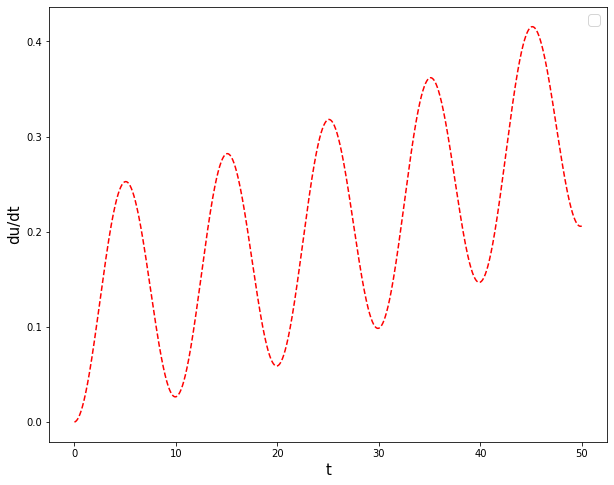

```python
plt.figure(figsize = (10, 8))
x = np.arange(0, 50, 0.01)
y = 0.12 * tf.math.exp(0.02 * x) - 0.12 * tf.math.cos(0.2 * np.pi * x)

plt.plot(x, y, '--r')
plt.legend(fontsize = 15)
plt.xlabel('t', fontsize = 15)
plt.ylabel('du/dt', fontsize = 15)
plt.show()
```

(2) Build the model

- There are no specific requirements for the model

```python
NN = tf.keras.models.Sequential([tf.keras.layers.Input((1, )),
                                 tf.keras.layers.Dense(units = 32, activation = 'tanh'),
                                 tf.keras.layers.Dense(units = 60, activation = 'tanh'),
                                 tf.keras.layers.Dense(units = 60, activation = 'tanh'),
                                 tf.keras.layers.Dense(units = 60, activation = 'tanh'),
                                 tf.keras.layers.Dense(units = 60, activation = 'tanh'),
                                 tf.keras.layers.Dense(units = 60, activation = 'tanh'),
                                 tf.keras.layers.Dense(units = 32, activation = 'tanh'),
                                 tf.keras.layers.Dense(units = 1)])

NN.summary()

optm = tf.keras.optimizers.Adam(learning_rate = 0.001)
```

```
Model: "sequential"
_________________________________________________________________
 Layer (type)                Output Shape              Param #
=================================================================
 dense (Dense)               (None, 32)                64

 dense_1 (Dense)             (None, 60)                1980

 dense_2 (Dense)             (None, 60)                3660

 dense_3 (Dense)             (None, 60)                3660

 dense_4 (Dense)             (None, 60)                3660

 dense_5 (Dense)             (None, 60)                3660

 dense_6 (Dense)             (None, 32)                1952

 dense_7 (Dense)             (None, 1)                 33

=================================================================
Total params: 18,669
Trainable params: 18,669
Non-trainable params: 0
_________________________________________________________________
```

(3) Define the ODE system we will use in this problem

- Hint: the rocket was launched from the ground (consider this condition as the initial condition)
- $u$ is the vertical displacement and $\frac{du}{dt}$ is the vertical velocity
- Multiply your IC_loss with 0.01

```python
def ode_system(t, net):

    t = t.reshape(-1, 1)
    t = np.vstack([t, [0]])
    t = tf.constant(t, dtype = tf.float32)
    t_0 = tf.zeros((1, 1))
    one = tf.zeros((1, 1))

    with tf.GradientTape() as tape:
        tape.watch(t)
        u = net(t)
        u_t = tape.gradient(u, t)

    ode_loss = u_t - (0.12 * tf.math.exp(0.02 * t) - 0.12 * tf.math.cos(0.2 * np.pi * t))
    IC_loss = 0.01 * (net(t_0) - one)

    square_loss = tf.square(ode_loss) + tf.square(IC_loss)
    total_loss = tf.reduce_mean(square_loss)

    return total_loss
```

(4) Define training data (train_t) and train the model

- Plot the loss curve
- Use 50 points as the training data (the points do not have to be integers)
- Set maximum value of the training data points as 50 (all training points t should be less than 50)

```
0.049300574
0.00011955602
3.235752e-05
7.86799e-06
1.3926441e-05
```

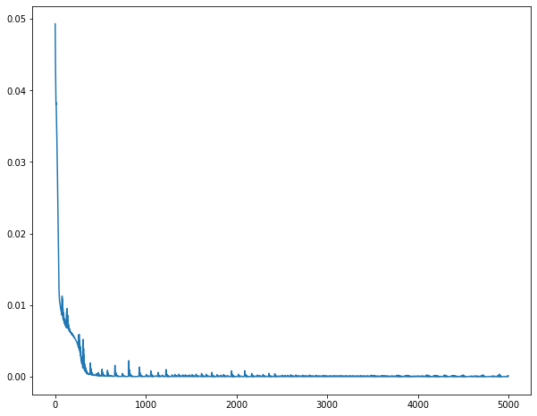

```python
train_t = (np.random.rand(50) * 50).reshape(-1, 1)
train_loss_record = []

for itr in range(5000):
    with tf.GradientTape() as tape:
        train_loss = ode_system(train_t, NN)
        train_loss_record.append(train_loss)

        grad_w = tape.gradient(train_loss, NN.trainable_variables)
        optm.apply_gradients(zip(grad_w, NN.trainable_variables))

    if itr % 1000 == 0:
        print(train_loss.numpy())

plt.figure(figsize = (10, 8))
plt.plot(train_loss_record)
plt.show()
```

(5) Compare the trained PINN model with ground truth equation (exact solution)

- Exact solution is given below
- Set your test data within the range of 0 to 50

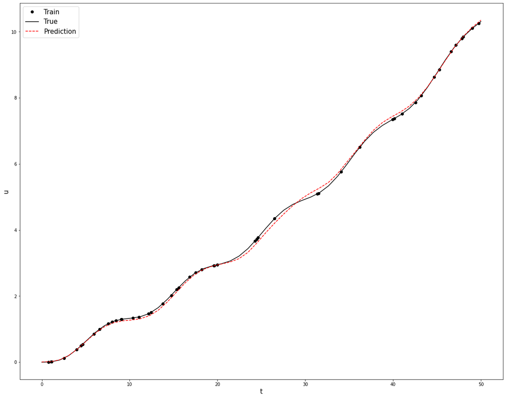

```python
test_t = np.linspace(0, 50, 50)
train_u = 6 * tf.math.exp(0.02 * train_t) - 0.6 / np.pi * tf.math.sin(0.2 * np.pi * train_t) - 6
true_u = 6 * tf.math.exp(0.02 * test_t) - 0.6 / np.pi * tf.math.sin(0.2 * np.pi * test_t) - 6
pred_u = NN.predict(test_t).ravel()

plt.figure(figsize = (20, 16))
plt.plot(train_t, train_u, 'ok', label = 'Train')
plt.plot(test_t, true_u, '-k',label = 'True')
plt.plot(test_t, pred_u, '--r', label = 'Prediction')
plt.legend(fontsize = 15)
plt.xlabel('t', fontsize = 15)
plt.ylabel('u', fontsize = 15)
plt.show()
```

# Problem 2. Burger's Equation (DeepXDE)

- Burger's Equation is a fundamental partial differential equation and convection–diffusion equation occurring in various areas of applied mathematics, such as fluid mechanics, nonlinear acoustics, gas dynamics, and traffic flow.
- For a given field ${\displaystyle u(x,t)}$ and diffusion coefficient (or kinematic viscosity, as in the original fluid mechanical context) ${\displaystyle \nu }$ , the general form of Burgers' equation (also known as viscous Burgers' equation) in one space dimension is the dissipative system:

$$ \begin{align*} {\partial u \over \partial t} + u{\partial u \over \partial x} = \nu {\partial^2 u \over \partial x^2} \end{align*} $$

- Dirichlet Boundary Conditions: ${\displaystyle u(-1,t) = u(1,t) = 0}$
- Initial Conditions: ${\displaystyle u(x,0) = -\sin (\pi x)}$

```python
import deepxde as dde
import numpy as np
from deepxde.backend.set_default_backend import set_default_backend
set_default_backend("tensorflow")
```

```
Using backend: tensorflow
```

```
Setting the default backend to "tensorflow". You can change it in the ~/.deepxde/config.json file or export the DDE_BACKEND environment variable. Valid options are: tensorflow.compat.v1, tensorflow, pytorch, jax, paddle (all lowercase)
```

(1) Define the PDE system

```python
def pde(x, y):
    dy_x = dde.grad.jacobian(y, x, i = 0, j = 0)
    dy_t = dde.grad.jacobian(y, x, i = 0, j = 1)
    dy_xx = dde.grad.hessian(y, x, i = 0, j = 0)
    return dy_t + y * dy_x - 0.01 / np.pi * dy_xx
```

(2) Define geometry, time domain, boundary condition, and initial condition

- Some are given for you

```python
geom = dde.geometry.Interval(-1, 1)
timedomain = dde.geometry.TimeDomain(0, 0.99)
geomtime = dde.geometry.GeometryXTime(geom, timedomain)

bc = dde.icbc.DirichletBC(geomtime,
                          lambda x: 0,
                          lambda _,
                          on_boundary: on_boundary)

ic = dde.icbc.IC(geomtime,
                 lambda x: -np.sin(np.pi * x[:, 0:1]),
                 lambda _,
                 on_initial: on_initial)

data = dde.data.TimePDE(geomtime,
                        pde,
                        [bc, ic],
                        num_domain = 2540,
                        num_boundary = 80,
                        num_initial = 160)
```

(3) Define network and hyper-parameters

- There are no specific requirements for the model

```python
net = dde.nn.FNN([2] + [20] * 3 + [1], "tanh", "Glorot normal")
model = dde.Model(data, net)

model.compile("adam", lr = 1e-3)
```

```
Compiling model...
'compile' took 0.002345 s
```

(4) Train the model for 15000 iterations

```python
model.train(iterations = 15000)
```

```
Training model...
```

[output not shown]

[output not shown]

[output not shown]

```
WARNING: AutoGraph could not transform <function <lambda> at 0x7efba4a36790> and will run it as-is.
Cause: could not parse the source code of <function <lambda> at 0x7efba4a36790>: no matching AST found among candidates:
# coding=utf-8
(lambda x, on: np.array([on_boundary(x[i], on[i]) for i in range(len(x))]))
To silence this warning, decorate the function with @tf.autograph.experimental.do_not_convert
Step      Train loss                        Test loss                         Test metric
0         [5.71e-03, 1.42e-02, 4.18e-01]    [5.71e-03, 1.42e-02, 4.18e-01]    []
1000      [4.04e-02, 7.01e-04, 5.50e-02]    [4.04e-02, 7.01e-04, 5.50e-02]    []
2000      [3.17e-02, 8.20e-05, 4.55e-02]    [3.17e-02, 8.20e-05, 4.55e-02]    []
3000      [1.79e-02, 1.60e-04, 1.98e-02]    [1.79e-02, 1.60e-04, 1.98e-02]    []
4000      [5.65e-03, 5.20e-05, 4.47e-03]    [5.65e-03, 5.20e-05, 4.47e-03]    []
5000      [3.82e-03, 2.22e-05, 2.86e-03]    [3.82e-03, 2.22e-05, 2.86e-03]    []
6000      [2.89e-03, 1.62e-05, 2.18e-03]    [2.89e-03, 1.62e-05, 2.18e-03]    []
7000      [2.25e-03, 1.21e-05, 1.79e-03]    [2.25e-03, 1.21e-05, 1.79e-03]    []
8000      [1.82e-03, 9.27e-06, 1.51e-03]    [1.82e-03, 9.27e-06, 1.51e-03]    []
9000      [1.75e-03, 1.04e-05, 1.29e-03]    [1.75e-03, 1.04e-05, 1.29e-03]    []
10000     [1.25e-03, 6.92e-06, 1.05e-03]    [1.25e-03, 6.92e-06, 1.05e-03]    []
11000     [1.06e-03, 5.86e-06, 8.43e-04]    [1.06e-03, 5.86e-06, 8.43e-04]    []
12000     [9.05e-04, 4.95e-06, 6.70e-04]    [9.05e-04, 4.95e-06, 6.70e-04]    []
13000     [7.90e-04, 4.54e-06, 5.32e-04]    [7.90e-04, 4.54e-06, 5.32e-04]    []
14000     [7.41e-04, 2.94e-06, 4.43e-04]    [7.41e-04, 2.94e-06, 4.43e-04]    []
15000     [6.35e-04, 4.07e-06, 3.58e-04]    [6.35e-04, 4.07e-06, 3.58e-04]    []

Best model at step 15000:
  train loss: 9.98e-04
  test loss: 9.98e-04
  test metric: []

'train' took 181.034382 s
```

```
(<deepxde.model.LossHistory at 0x7efba4a5c550>,
 <deepxde.model.TrainState at 0x7efba4a5c580>)
```

(5) Evaluate the PINN model with data

- Download X data [here](https://www.dropbox.com/s/ts69folmkw0toyl/Xdata.npy?dl=1)
- X data is composed of ${\displaystyle (x,t)}$ data
- Download y data [here](https://www.dropbox.com/s/7z8v9b7tfy1cw8z/ydata.npy?dl=1)
- y data is corresponding $u$ value for each ${\displaystyle (x,t)}$ pair
- With the data, compute the L2 relative error between the predicted $u$ value and ground truth $u$ value

```python
X = np.load("./data_files/Xdata.npy")
y_true = np.load("./data_files/ydata.npy")
y_pred = model.predict(X)
f = model.predict(X, operator = pde)

print("L2 relative error:", dde.metrics.l2_relative_error(y_true, y_pred))
```

```
L2 relative error: 0.03901923478096179
```